# Questions:-

# 4. Check the statistical summary of both numerical and categorical columns and write your inferences.

```python
#The statistical summary of  numerical.
df_yt.describe()

#The numerical values in this dataset has wide range of data distribution because of higher standard deivation
```

|  | view_count | likes | dislikes | comment_count |
| --- | --- | --- | --- | --- |
| count | 37264.00000 | 37264.00000 | 37264.00000 | 37264.00000 |
| mean | 5710821.45003 | 167286.69700 | 4996.43412 | 9966.95315 |
| std | 24313037.50711 | 538493.10269 | 30751.93784 | 117346.46657 |
| min | 20368.00000 | 22.00000 | 3.00000 | 1.00000 |
| 25% | 514130.50000 | 13317.25000 | 282.75000 | 914.00000 |
| 50% | 1321860.50000 | 42556.00000 | 798.00000 | 2347.00000 |
| 75% | 3674527.25000 | 130966.50000 | 2466.25000 | 6212.00000 |
| max | 1322796924.00000 | 31837675.00000 | 2397733.00000 | 16071029.00000 |

```python
#The statistical summary of  categorical columns.
df_yt.describe(include='object')
#There are 10891 unique channel are present in this dataset.
#Among 37264 only 10813 unique channel names are aviable in this dataset.
```

|  | video_id | title | channel_id | channel_title | published_at | tags | description | comments |
| --- | --- | --- | --- | --- | --- | --- | --- | --- |
| count | 37264 | 37264 | 37264 | 37264 | 37264 | 37264 | 37264 | 37264 |
| unique | 37264 | 36958 | 10891 | 10813 | 36617 | 28705 | 35479 | 37264 |
| top | --0bCF-iK2E | www | UCNAf1k0yIjyGu3k9BwAg3lg | Sky Sports Football | 2020-10-16 04:00:10 |  |  | Respect to Dortmund fans,must be sad losing hi... |
| freq | 1 | 21 | 533 | 533 | 6 | 3808 | 587 | 1 |

# 5. Convert datatype of column published_at from object to pandas datetime.

```python
#Convert datatype of column published_at from object to pandas datetime.
df_yt['published_at'] = pd.to_datetime(df_yt['published_at'])
df_yt.dtypes
```

```
video_id                 object
title                    object
channel_id               object
channel_title            object
published_at     datetime64[ns]
view_count                int64
likes                     int64
dislikes                  int64
comment_count             int64
tags                     object
description              object
comments                 object
dtype: object
```

# 6. Create a new column as 'published_month' using the column published_at (display the months only)

```python
#Create a new column as 'published_month' using the column published_at (display the months only)
df_yt['published_month'] = df_yt['published_at'].dt.month
df_yt['published_month']
```

```
0         7
1         6
2         9
3         3
4        12
         ..
37417     2
37418     1
37419     6
37420    10
37421     5
Name: published_month, Length: 37264, dtype: int64
```

```python
df_yt
```

|  | video_id | title | channel_id | channel_title | published_at | view_count | likes | dislikes | comment_count | tags | description | comments | published_month |
| --- | --- | --- | --- | --- | --- | --- | --- | --- | --- | --- | --- | --- | --- |
| 0 | --0bCF-iK2E | Jadon Sancho Magical Skills & Goals | UC6UL29enLNe4mqwTfAyeNuw | Bundesliga | 2021-07-01 10:00:00 | 1048888 | 19515 | 226 | 1319 | football soccer ftbol alemn Bundesliga season ... | Enjoy the best skills and goals from Jadon San... | Respect to Dortmund fans,must be sad losing hi... | 7 |
| 1 | --14w5SOEUs | Migos - Avalanche (Official Video) | UCGIelM2Dj3zza3xyV3pL3WQ | MigosVEVO | 2021-06-10 16:00:00 | 15352638 | 359277 | 7479 | 18729 | Migos Avalanche Quality Control Music/Motown R... | Watch the the official video for Migos - "Aval... | Migos just makes me want to live my live to th... | 6 |
| 2 | --40TEbZ9Is | Supporting Actress in a Comedy: 73rd Emmys | UClBKH8yZRcM4AsRjDVEdjMg | Television Academy | 2021-09-20 01:03:32 | 925281 | 11212 | 401 | 831 |  | Hannah Waddingham wins the Emmy for Supporting... | Hannah's energy bursts through any screen. Wel... | 9 |
| 3 | --4tfbSyYDE | JO1'YOUNG (JO1 ver.)' PERFORMANCE VIDEO | UCsmXiDP8S40uBeJYxvyulmA | JO1 | 2021-03-03 10:00:17 | 2641597 | 39131 | 441 | 3745 | PRODUCE101JAPAN JO1 TheSTAR STA... | JO1'YOUNG (JO1 ver.)' PERFORMANCE VIDEO\n\n---... | youngVer>< REN is really PERFECT. It's not ju... | 3 |
| 4 | --DKkzWVh-E | Why Retaining Walls Collapse | UCMOqf8ab-42UUQIdVoKwjlQ | Practical Engineering | 2021-12-07 13:00:00 | 715724 | 32887 | 367 | 1067 | retaining wall New Jersey highway Direct Conne... | One of the most important (and innocuous) part... | Keep up with all my projects here: https://pr... | 12 |
| ... | ... | ... | ... | ... | ... | ... | ... | ... | ... | ... | ... | ... | ... |
| 37417 | zzd4ydafGR0 | Lil Tjay - Calling My Phone (feat. 6LACK) [Off... | UCEB4a5o_6KfjxHwNMnmj54Q | Lil Tjay | 2021-02-12 05:03:49 | 120408275 | 2180780 | 35871 | 81360 | Lil Tjay Steady Calling My Phone Calling My Ph... | Official video for "Calling My Phone" by Lil T... | 'DESTINED 2 WIN' OUT NOW !! https://liltjay.ln... | 2 |
| 37418 | zziBybeSAtw | PELICANS at LAKERS \| FULL GAME HIGHLIGHTS \| Ja... | UCWJ2lWNubArHWmf3FIHbfcQ | NBA | 2021-01-16 05:39:05 | 2841917 | 20759 | 1049 | 2624 | NBA G League Basketball game-0022000187 Lakers... | PELICANS at LAKERS \| FULL GAME HIGHLIGHTS \| Ja... | Montrezl Harrell is going crazy with the rebou... | 1 |
| 37419 | zzk09ESX7e0 | [MV] (MAMAMOO) - Where Are We Now | UCuhAUMLzJxlP1W7mEk0_6lA | MAMAMOO | 2021-06-02 09:00:10 | 13346678 | 720854 | 4426 | 90616 | MAMAMOO WAW WAW MAMAMOO WAW Where Are We Now... | [MV] (MAMAMOO) - Where Are We Now\n\nInstagra... | I honestly do not know why this song hit so ha... | 6 |
| 37420 | zzmQEb0Em5I | FELLIPE ESCUDERO- Master Podcast #12 | UC8NjnNWMsRqq11NYvHAQb1g | Master Podcast | 2020-10-20 20:59:30 | 252057 | 19198 | 1234 | 1471 | master masterpodcast lord lord vinheteiro z z ... | DOCTOR HAIR\nhttps://www.thedoctorhair.com/?fb... | Foi um prazer passar esta tarde com vocs debat... | 10 |
| 37421 | zzxPZwaA-8w | Gareth Bale brace secures dramatic comeback on... | UCEg25rdRZXg32iwai6N6l0w | Tottenham Hotspur | 2021-05-23 21:00:31 | 2252090 | 34063 | 868 | 2004 | Spurs Tottenham Hotspur Tottenham Leicester ... | Two minute highlights from Tottenham Hotspur's... | Thank you Kane for everything you have given t... | 5 |

37264 rows × 13 columns

# 7. Replace the numbers in the column published_month as names of the months i,e., 1 as 'Jan', 2 as 'Feb' and so on.....

```python
df_yt['published_month'] = df_yt['published_at'].dt.strftime('%B')
```

```python
df_yt
```

|  | video_id | title | channel_id | channel_title | published_at | view_count | likes | dislikes | comment_count | tags | description | comments | published_month |
| --- | --- | --- | --- | --- | --- | --- | --- | --- | --- | --- | --- | --- | --- |
| 0 | --0bCF-iK2E | Jadon Sancho Magical Skills & Goals | UC6UL29enLNe4mqwTfAyeNuw | Bundesliga | 2021-07-01 10:00:00 | 1048888 | 19515 | 226 | 1319 | football soccer ftbol alemn Bundesliga season ... | Enjoy the best skills and goals from Jadon San... | Respect to Dortmund fans,must be sad losing hi... | July |
| 1 | --14w5SOEUs | Migos - Avalanche (Official Video) | UCGIelM2Dj3zza3xyV3pL3WQ | MigosVEVO | 2021-06-10 16:00:00 | 15352638 | 359277 | 7479 | 18729 | Migos Avalanche Quality Control Music/Motown R... | Watch the the official video for Migos - "Aval... | Migos just makes me want to live my live to th... | June |
| 2 | --40TEbZ9Is | Supporting Actress in a Comedy: 73rd Emmys | UClBKH8yZRcM4AsRjDVEdjMg | Television Academy | 2021-09-20 01:03:32 | 925281 | 11212 | 401 | 831 |  | Hannah Waddingham wins the Emmy for Supporting... | Hannah's energy bursts through any screen. Wel... | September |
| 3 | --4tfbSyYDE | JO1'YOUNG (JO1 ver.)' PERFORMANCE VIDEO | UCsmXiDP8S40uBeJYxvyulmA | JO1 | 2021-03-03 10:00:17 | 2641597 | 39131 | 441 | 3745 | PRODUCE101JAPAN JO1 TheSTAR STA... | JO1'YOUNG (JO1 ver.)' PERFORMANCE VIDEO\n\n---... | youngVer>< REN is really PERFECT. It's not ju... | March |
| 4 | --DKkzWVh-E | Why Retaining Walls Collapse | UCMOqf8ab-42UUQIdVoKwjlQ | Practical Engineering | 2021-12-07 13:00:00 | 715724 | 32887 | 367 | 1067 | retaining wall New Jersey highway Direct Conne... | One of the most important (and innocuous) part... | Keep up with all my projects here: https://pr... | December |
| ... | ... | ... | ... | ... | ... | ... | ... | ... | ... | ... | ... | ... | ... |
| 37417 | zzd4ydafGR0 | Lil Tjay - Calling My Phone (feat. 6LACK) [Off... | UCEB4a5o_6KfjxHwNMnmj54Q | Lil Tjay | 2021-02-12 05:03:49 | 120408275 | 2180780 | 35871 | 81360 | Lil Tjay Steady Calling My Phone Calling My Ph... | Official video for "Calling My Phone" by Lil T... | 'DESTINED 2 WIN' OUT NOW !! https://liltjay.ln... | February |
| 37418 | zziBybeSAtw | PELICANS at LAKERS \| FULL GAME HIGHLIGHTS \| Ja... | UCWJ2lWNubArHWmf3FIHbfcQ | NBA | 2021-01-16 05:39:05 | 2841917 | 20759 | 1049 | 2624 | NBA G League Basketball game-0022000187 Lakers... | PELICANS at LAKERS \| FULL GAME HIGHLIGHTS \| Ja... | Montrezl Harrell is going crazy with the rebou... | January |
| 37419 | zzk09ESX7e0 | [MV] (MAMAMOO) - Where Are We Now | UCuhAUMLzJxlP1W7mEk0_6lA | MAMAMOO | 2021-06-02 09:00:10 | 13346678 | 720854 | 4426 | 90616 | MAMAMOO WAW WAW MAMAMOO WAW Where Are We Now... | [MV] (MAMAMOO) - Where Are We Now\n\nInstagra... | I honestly do not know why this song hit so ha... | June |
| 37420 | zzmQEb0Em5I | FELLIPE ESCUDERO- Master Podcast #12 | UC8NjnNWMsRqq11NYvHAQb1g | Master Podcast | 2020-10-20 20:59:30 | 252057 | 19198 | 1234 | 1471 | master masterpodcast lord lord vinheteiro z z ... | DOCTOR HAIR\nhttps://www.thedoctorhair.com/?fb... | Foi um prazer passar esta tarde com vocs debat... | October |
| 37421 | zzxPZwaA-8w | Gareth Bale brace secures dramatic comeback on... | UCEg25rdRZXg32iwai6N6l0w | Tottenham Hotspur | 2021-05-23 21:00:31 | 2252090 | 34063 | 868 | 2004 | Spurs Tottenham Hotspur Tottenham Leicester ... | Two minute highlights from Tottenham Hotspur's... | Thank you Kane for everything you have given t... | May |

37264 rows × 13 columns

```python
df_yt.columns
```

```
Index(['video_id', 'title', 'channel_id', 'channel_title', 'published_at',
       'view_count', 'likes', 'dislikes', 'comment_count', 'tags',
       'description', 'comments', 'published_month'],
      dtype='object')
```

```python
df_yt.columns
```

```
Index(['video_id', 'title', 'channel_id', 'channel_title', 'published_at',
       'view_count', 'likes', 'dislikes', 'comment_count', 'tags',
       'description', 'comments', 'published_month'],
      dtype='object')
```

# 8. Find the number of videos published each month and arrange the months in a decreasing order based on the video count.

```python
#grouping by months


video_month = df_yt.groupby(('published_month'))
```

```python
#apply aggregate function onto grouped month

video_month['title'].count().sort_values(ascending=False)
```

```
published_month
October      4976
September    4854
November     4821
August       4250
December     3063
July         2331
June         2305
March        2248
February     2125
April        2119
January      2099
May          2073
Name: title, dtype: int64
```

# 9. Find the count of unique video_id, channel_id and channel_title.

```python
#The count of unique video_id.

len(df_yt['video_id'].unique())
```

```
37264
```

```python
#The count of unique channel_id.

len(df_yt['channel_id'].unique())
```

```
10891
```

```python
#The count of unique channel_title.

len(df_yt['channel_title'].unique())
```

```
10813
```

# 10. Find the top10 channel names having the highest number of videos in the dataset and the bottom10 having lowest number of videos.

```python
# The top 10 channel names having the highest number of videos

df_yt.groupby(by='channel_title')[['video_id']].count().sort_values(by='video_id',ascending=False).head(10)
```

| channel_title | video_id |
| --- | --- |
| Sky Sports Football | 533 |
| The United Stand | 301 |
| BT Sport | 246 |
| NBA | 209 |
| NFL | 162 |
| WWE | 122 |
| SSSniperWolf | 99 |
| SSundee | 98 |
| FORMULA 1 | 87 |
| NHL | 86 |

```python
# The bottom 10 channel names having the highest number of videos.

df_yt.groupby(by='channel_title')[['video_id']].count().sort_values(by='video_id',ascending=False).tail(10)
```

| channel_title | video_id |
| --- | --- |
| Karikku Tuned | 1 |
| Karen Bustillos | 1 |
| Karen Aslanyan | 1 |
| Karchez | 1 |
| Karate Combat | 1 |
| Kaptain Kuba | 1 |
| Kanye West | 1 |
| Kannur kitchen | 1 |
| Kannada Cinema | 1 |
| zoom | 1 |

# 11. Find the title of the video which has the maximum number of likes and the title of the video having minimum likes and write your inferences.

```python
df_yt.groupby(by = 'likes')[['title']].max().tail(1)

#Among 36958 unique title BTS () 'Dynamite' Official MV as more number of likes
```

| likes | title |
| --- | --- |
| 31837675 | BTS () 'Dynamite' Official MV |

```python
df_yt.groupby(by ='likes' )[['title']].min().head(1)
#Among 36958 unique title leading th charge has less number of likes.
```

| likes | title |
| --- | --- |
| 22 | Leading the Charge \| Circle K |

# 12. Find the title of the video which has the maximum number of dislikes and the title of the video having minimum dislikes and write your inferences.

```python
df_yt.groupby(by ='dislikes')[['title']].max().tail(1)
#Among 36958 unique title cuties has more number of dilikes.
```

| dislikes | title |
| --- | --- |
| 2397733 | Cuties \| Official Trailer \| Netflix |

```python
df_yt.groupby(by = 'dislikes')[['title']].min().head(1)
#Among 36958 unique title Tims For Good: A Taste Of The Familiar has less number of dilikes.
```

| dislikes | title |
| --- | --- |
| 3 | Tims For Good: A Taste Of The Familiar |

# 13. Does the number of views have any effect on how many people disliked the video? Support your answer with a metric and a plot.

```python
df_yt.columns
```

```
Index(['video_id', 'title', 'channel_id', 'channel_title', 'published_at',
       'view_count', 'likes', 'dislikes', 'comment_count', 'tags',
       'description', 'comments', 'published_month'],
      dtype='object')
```

```python
#First we can create the correlation relationship with this two variable View count and Dislikes.
cor_twovar = df_yt['view_count'].corr(df_yt['dislikes'])
cor_twovar

#The correlation of this two_var is 0.684575 which is positive
```

```
0.6845758297072598
```

```python
df_yt.columns
```

```
Index(['video_id', 'title', 'channel_id', 'channel_title', 'published_at',
       'view_count', 'likes', 'dislikes', 'comment_count', 'tags',
       'description', 'comments', 'published_month'],
      dtype='object')
```

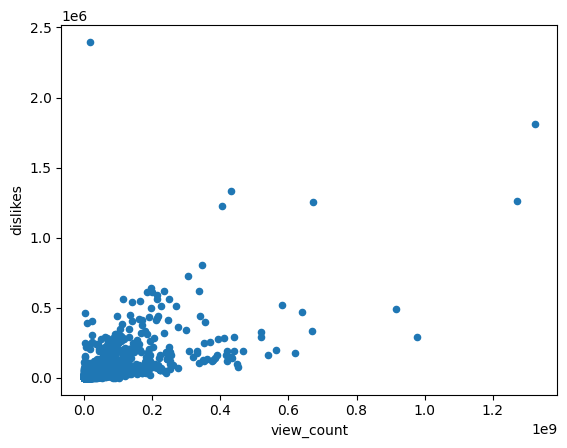

```python
df_yt.plot.scatter(x='view_count',y='dislikes')
plt.show()
#IF the number of views increases the no.of dislikes also tend to increases.
```

# 14. Display all the information about the videos that were published in January, and mention the count of videos that were published in January.

```python
jan_videos = df_yt[df_yt['published_at'].dt.month==1]
jan_videos
```

|  | video_id | title | channel_id | channel_title | published_at | view_count | likes | dislikes | comment_count | tags | description | comments | published_month |
| --- | --- | --- | --- | --- | --- | --- | --- | --- | --- | --- | --- | --- | --- |
| 27 | -2Gwm7QfBnE | Q&A With Naisha | UCYwNMbogQFzMccPSuy-pPWg | MianTwins | 2021-01-21 00:05:47 | 872372 | 38626 | 239 | 621 |  | Hey Guys!!! this has been the most requested v... | I feel like Nate and Aishas personality match ... | January |
| 48 | -4sfXSHSxzA | SURPRISING BRENT WITH HIS TIKTOK CRUSH!! | UCPpATKqmMV-CNRNWYaDUwiA | Alexa Rivera | 2021-01-16 21:40:04 | 6504784 | 262477 | 5779 | 7907 |  | He had no idea! Thank you guys so much for wat... | Thank you guys for watching and don't forget t... | January |
| 95 | -AJD1Fc5rpQ | WE ARE HAVING A BABY! \| finding out i'm pregna... | UCVsTboAhpnuL6j-tDePvNwQ | Tess Christine | 2021-01-03 21:53:48 | 533084 | 38965 | 119 | 1650 |  | I am so happy to tell you that I am pregnant!!... | Okay I needed a moment to collect my thoughts ... | January |
| 103 | -AuJiwjsmWk | Do Ugly Foods Taste Worse? Taste Test | UCzpCc5n9hqiVC7HhPwcIKEg | Good Mythical MORE | 2021-01-19 11:00:01 | 1057077 | 22526 | 531 | 773 | gmm good mythical morning rhettandlink rhett a... | Today, we're doing a blind taste test to deter... | "there's nothing wrong with it being bent"\nI ... | January |
| 182 | -JhqO2KWr5U | Schlatt gets fit | UCWZp4y1jqBuvLtiyxSs_ZBw | Big guy | 2021-01-24 22:50:57 | 1724965 | 119431 | 325 | 1578 | jschlatt big guy jschlatt highlights schlatt j... | #jschlatt #schlatt #bigguy #short | Schlatt is single handedly wiping out all the ... | January |
| ... | ... | ... | ... | ... | ... | ... | ... | ... | ... | ... | ... | ... | ... |
| 37300 | zmzFL5bG-jc | DEVINE MON PERSONNAGE AVANT AKINATOR ! (c'est ... | UCIlr3byh6wmXgcPx_Tm9Ocw | Piwerre | 2021-01-16 16:12:19 | 670357 | 54462 | 832 | 1249 | Piwerre frere de michou crouton among us devin... | Discord Piwerre : https://discord.gg/QBduPgAA... | Mdr michou quand c'est pas ses tournage il fou... | January |
| 37329 | zpzjex7qwrA | Lampard Sacked Within Days Rorys Misery \| Chel... | UCkD-ZOixI0a9FjIExDsHsbg | The Kick Off | 2021-01-03 20:13:49 | 428646 | 12060 | 296 | 1505 | Premier league Chelsea chelsea 1-3 Man City Ch... | The Kick Off watched Manchester City destroy C... | True Its like a fighter who Geordie But I thou... | January |
| 37345 | zqyv-B6mnBM | Lil Wayne - Ain't Got Time (Audio) | UCO9zJy7HWrIS3ojB4Lr7Yqw | Lil Wayne | 2021-01-21 05:00:10 | 2238244 | 58925 | 2365 | 5539 | lil wayne weezy weezy wednesday wayne carter y... | Official audio for Lil Wayne "Ain't Got Time",... | RIP Juice Wrld, wrote that on two cups, pour o... | January |
| 37383 | zwfu1-24T7Q | PRADA Cup Day 1 \| Full Race Replay \| PRADA Cup... | UCo15ZYO_XDRU9LI30OPtxAg | America's Cup | 2021-01-15 04:07:55 | 317382 | 2008 | 83 | 192 | America's Cup Americas Cup AC36 AC75 Presented... | The opening day of the PRADA Cup in Auckland, ... | Incredible how these boats evolve in a short t... | January |
| 37418 | zziBybeSAtw | PELICANS at LAKERS \| FULL GAME HIGHLIGHTS \| Ja... | UCWJ2lWNubArHWmf3FIHbfcQ | NBA | 2021-01-16 05:39:05 | 2841917 | 20759 | 1049 | 2624 | NBA G League Basketball game-0022000187 Lakers... | PELICANS at LAKERS \| FULL GAME HIGHLIGHTS \| Ja... | Montrezl Harrell is going crazy with the rebou... | January |

2099 rows × 13 columns

```python
jan_videos['published_at'].count()
```

```
2099
```